| title:probability and simulation |
| --- |
| author:vardaan kapoor |
| output:html-document |

### CONCEPT OF BINOMIAL DISTRIBUTIONS

- discrete distributions which consider the number ofsuccesses in a fixed number of trials n ### BINS ACRONYM
- properties of binomial random variable
- $B$ stands for binary outcomes of trial n-either success or failure in the trial
- $I$ stands for independence of trials’ results-result of one trial doesn’t affect the result of another
- $N$ stands for fixed sample size(doesn’t depend on the outcomes)
- $S$ stands for same probability where each trial has the same probability of failure or success

### BINOMIAL MOMENTS

- mean=$\mu=np$
- variance=$\sigma^2=np(1-p)$
- standard deviation=$\sigma=\sqrt{np(1-p)}$
- use the function `rbinom` to calculate random binomial variables($b=NUMBER\quad OF\quad VARIABLES\quad WE\quad WANT$ while n and p remain the same)

```r
binomial=tibble(x=rbinom(1000000,100,0.5))
binomial %>% summarize(mean=mean(x),variance=var(x),sd=sd(x)) %>% as.data.frame()
```

```
##      mean variance       sd
## 1 50.0009 24.93828 4.993824
```

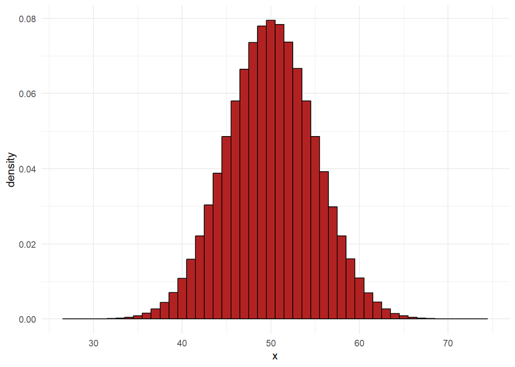

```r
ggplot(binomial,aes(x=x))+geom_histogram(aes(y=after_stat(density)),center=50,binwidth=1,color="black",fill="firebrick")+theme_minimal()
```

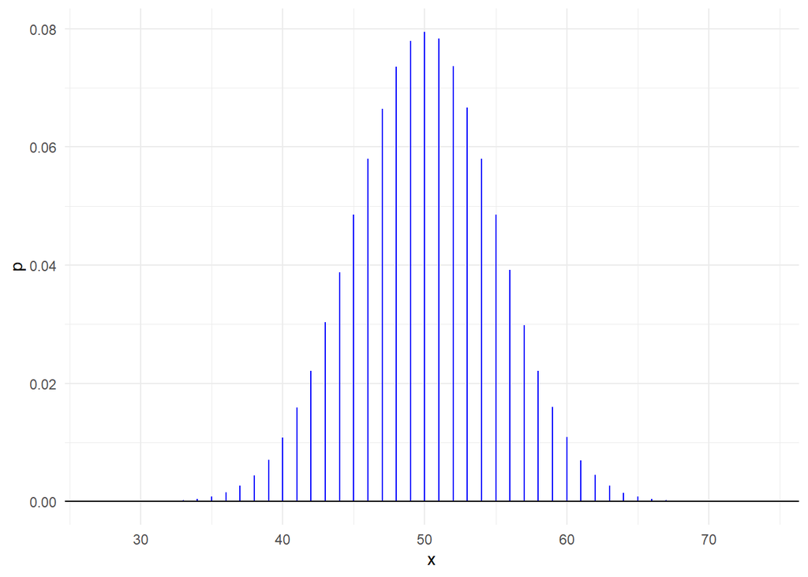

```r
binomial %>% count(x) %>% ungroup() %>% mutate(p=n/sum(n)) %>% ggplot(aes(x=x,y=p,xend=x,yend=0))+geom_segment(color="blue")+geom_hline(yintercept=0)+theme_minimal()
```

### explore graphs and arrange them using standard libraries

- use egg library to get the ggarrange() method
- get a grid using combinations of many values-use expand_grid() method
- iterate over the rows of the data frame-use pmap() method
- .x is used for 1st argument,.y is used for 2nd argument

[figure not shown]

```r
n_options=2^seq(0,10,by=1)
p_options=c(0.1,0.5,0.9)
binomial_plots=expand.grid(n_options,p_options) %>% pmap(~{gbinom(
  .x,.y,color=if_else(.y==0.1,"red",if_else(.y==0.5,"green","blue")),scale=TRUE)+theme_minimal()
})
#steps:expand the dataframe with expand_grid->use pmap to get to each column each of which contains a value of n and p
ggarrange(plots=binomial_plots,ncol=length(p_options),nrow=length(n_options))
```